# BDA PROJECT

## Chicago Crime Analysis Using Apache Spark and Hadoop

### Intializing

```python
import numpy as np
import datetime
import pandas as pd
import seaborn as sns
import matplotlib.pyplot as plt
from pyspark.sql.functions import *
from pyspark.ml.clustering import KMeans
from pyspark.ml.feature import VectorAssembler
from pyspark.ml.feature import StandardScaler
from pyspark.ml.classification import LogisticRegression
from pyspark.ml.feature import StringIndexer, VectorAssembler
from pyspark.ml.classification import DecisionTreeClassifier
from pyspark.ml.evaluation import MulticlassClassificationEvaluator
from pyspark.sql import functions as F
from pyspark.sql.functions import when
from pyspark.ml import Pipeline
```

The data has been uploaded on a local hdfs cluster using Hadoop. Creating a SparkSession to connect to this cluster.

```python
from pyspark.sql import SparkSession

# Create Spark session
spark = SparkSession.builder \
    .appName("Crime Data Analysis") \
    .config("spark.hadoop.fs.defaultFS", "hdfs://localhost:9000") \
    .getOrCreate()
```

### Reading Data

This document lists the Chicago crime data files uploaded to HDFS. Each file contains records of incidents reported to the Chicago Police Department.

## Uploaded Files to HDFS

| File Name | Size (bytes) | Last Modified |
| --- | --- | --- |
| `/data/Chicago_Crimes_2001_to_2004.csv` | 475,343,924 | 2024-10-20 12:21 |
| `/data/Chicago_Crimes_2005_to_2007.csv` | 471,278,284 | 2024-10-20 12:22 |
| `/data/Chicago_Crimes_2008_to_2011.csv` | 677,693,675 | 2024-10-20 12:22 |
| `/data/Chicago_Crimes_2012_to_2017.csv` | 366,804,568 | 2024-10-20 12:22 |

## Description of Files

- **Chicago_Crimes_2001_to_2004.csv**: Contains crime incident data from the years 2001 to 2004.
- **Chicago_Crimes_2005_to_2007.csv**: Contains crime incident data from the years 2005 to 2007.
- **Chicago_Crimes_2008_to_2011.csv**: Contains crime incident data from the years 2008 to 2011.
- **Chicago_Crimes_2012_to_2017.csv**: Contains crime incident data from the years 2012 to 2017.

```python
df = spark.read.csv("hdfs://localhost:9000/data/*", header=True, inferSchema=True)
```

```python
df = df.repartition(4)
```

```python
df = df.na.drop()
```

```python
df = df.cache()
```

```python
df.printSchema()
```

```
root
 |-- _c0: integer (nullable = true)
 |-- ID: integer (nullable = true)
 |-- Case Number: string (nullable = true)
 |-- Date: string (nullable = true)
 |-- Block: string (nullable = true)
 |-- IUCR: string (nullable = true)
 |-- Primary Type: string (nullable = true)
 |-- Description: string (nullable = true)
 |-- Location Description: string (nullable = true)
 |-- Arrest: string (nullable = true)
 |-- Domestic: string (nullable = true)
 |-- Beat: string (nullable = true)
 |-- District: string (nullable = true)
 |-- Ward: string (nullable = true)
 |-- Community Area: string (nullable = true)
 |-- FBI Code: string (nullable = true)
 |-- X Coordinate: string (nullable = true)
 |-- Y Coordinate: string (nullable = true)
 |-- Year: string (nullable = true)
 |-- Updated On: string (nullable = true)
 |-- Latitude: string (nullable = true)
 |-- Longitude: string (nullable = true)
 |-- Location: string (nullable = true)
```

- **ID**: Unique identifier for the record.
- **Case Number**: The Chicago Police Department RD Number (Records Division Number), which is unique to the incident.
- **Date**: Date when the incident occurred; this is sometimes a best estimate.
- **Block**: The partially redacted address where the incident occurred, placing it on the same block as the actual address.
- **IUCR**: The Illinois Uniform Crime Reporting code. This is directly linked to the Primary Type and Description. See the list of IUCR codes at [IUCR Codes](https://data.cityofchicago.org/d/c7ck-438e).
- **Primary Type**: The primary description of the IUCR code.
- **Description**: The secondary description of the IUCR code, a subcategory of the primary description.
- **Location Description**: Description of the location where the incident occurred.
- **Arrest**: Indicates whether an arrest was made.
- **Domestic**: Indicates whether the incident was domestic-related as defined by the Illinois Domestic Violence Act.
- **Beat**: Indicates the beat where the incident occurred. A beat is the smallest police geographic area – each beat has a dedicated police beat car. Three to five beats make up a police sector, and three sectors make up a police district. The Chicago Police Department has 22 police districts. See the beats at [Beats](https://data.cityofchicago.org/d/aerh-rz74).
- **District**: Indicates the police district where the incident occurred. See the districts at [Districts](https://data.cityofchicago.org/d/fthy-xz3r).
- **Ward**: The ward (City Council district) where the incident occurred. See the wards at [Wards](https://data.cityofchicago.org/d/sp34-6z76).
- **Community Area**: Indicates the community area where the incident occurred. Chicago has 77 community areas. See the community areas at [Community Areas](https://data.cityofchicago.org/d/cauq-8yn6).
- **FBI Code**: Indicates the crime classification as outlined in the FBI's National Incident-Based Reporting System (NIBRS). See the Chicago Police Department listing of these classifications at [FBI Code](http://gis.chicagopolice.org/clearmap_crime_sums/crime_types.html).
- **X Coordinate**: The x coordinate of the location where the incident occurred in State Plane Illinois East NAD 1983 projection. This location is shifted from the actual location for partial redaction but falls on the same block.
- **Y Coordinate**: The y coordinate of the location where the incident occurred in State Plane Illinois East NAD 1983 projection. This location is shifted from the actual location for partial redaction but falls on the same block.
- **Year**: Year the incident occurred.
- **Updated On**: Date and time the record was last updated.
- **Latitude**: The latitude of the location where the incident occurred. This location is shifted from the actual location for partial redaction but falls on the same block.
- **Longitude**: The longitude of the location where the incident occurred. This location is shifted from the actual location for partial redaction but falls on the same block.
- **Location**: The location where the incident occurred in a format that allows for creation of maps and other geographic operations on this data portal. This location is shifted from the actual location for partial redaction but falls on the same block. on the same block.

```python
df.show(4)
```

```
+-------+-------+-----------+--------------------+-------------------+----+-------------------+--------------------+--------------------+------+--------+----+--------+----+--------------+--------+------------+------------+----+--------------------+------------+-------------+--------------------+
|    _c0|     ID|Case Number|                Date|              Block|IUCR|       Primary Type|         Description|Location Description|Arrest|Domestic|Beat|District|Ward|Community Area|FBI Code|X Coordinate|Y Coordinate|Year|          Updated On|    Latitude|    Longitude|            Location|
+-------+-------+-----------+--------------------+-------------------+----+-------------------+--------------------+--------------------+------+--------+----+--------+----+--------------+--------+------------+------------+----+--------------------+------------+-------------+--------------------+
| 819798|6895333|   HR302296|01/01/2001 09:00:...|  069XX N TONTY AVE|0841|              THEFT|FINANCIAL ID THEF...|           RESIDENCE| False|   False|1621|    16.0|41.0|          12.0|      06|   1136246.0|   1945812.0|2001|05/15/2009 01:04:...|42.007479543|-87.774074987|(42.007479543, -8...|
|4018739|1911975|    G772146|10/19/2001 12:00:...|   002XX N CLARK ST|1205| DECEPTIVE PRACTICE|THEFT BY LESSEE,N...|               OTHER|  True|   False| 113|     1.0|42.0|          32.0|      11|   1175457.0|   1901885.0|2001|08/17/2015 03:03:...|41.886149136|-87.631134384|(41.886149136, -8...|
|4118252|1960310|   HH150725|01/26/2002 10:50:...|    063XX S TROY ST|0910|MOTOR VEHICLE THEFT|          AUTOMOBILE|              STREET| False|   False| 823|     8.0|15.0|          66.0|      07|   1156478.0|   1862385.0|2002|04/15/2016 08:55:...|41.778161356|-87.701895799|(41.778161356, -8...|
|3765563|1595721|    G365548|06/19/2001 12:00:...|083XX S SAGINAW AVE|0610|           BURGLARY|      FORCIBLE ENTRY|    RESIDENCE-GARAGE| False|   False| 423|     4.0| 7.0|          46.0|      05|   1195326.0|   1850064.0|2001|03/31/2006 10:03:...|41.743480598|-87.559885309|(41.743480598, -8...|
+-------+-------+-----------+--------------------+-------------------+----+-------------------+--------------------+--------------------+------+--------+----+--------+----+--------------+--------+------------+------------+----+--------------------+------------+-------------+--------------------+
only showing top 4 rows
```

```python
print(df.count())
```

```
7145216
```

In total there are over `seven million` records

### Exploratory Data Analysis

#### Crime Type vs Count

Analyzing the types of crimes to determine which ones are committed most frequently.

```python
crime_type_groups = df.groupBy('Primary Type').count()
```

```python
crime_type_counts = crime_type_groups.orderBy('count', ascending=False)
```

```python
crime_type_counts.show(truncate=False)
```

```
+--------------------------------+-------+
|Primary Type                    |count  |
+--------------------------------+-------+
|THEFT                           |1476357|
|BATTERY                         |1298240|
|CRIMINAL DAMAGE                 |835284 |
|NARCOTICS                       |796053 |
|OTHER OFFENSE                   |440882 |
|ASSAULT                         |432898 |
|BURGLARY                        |430571 |
|MOTOR VEHICLE THEFT             |328764 |
|ROBBERY                         |271450 |
|DECEPTIVE PRACTICE              |247713 |
|CRIMINAL TRESPASS               |207722 |
|PROSTITUTION                    |76768  |
|WEAPONS VIOLATION               |70352  |
|PUBLIC PEACE VIOLATION          |54362  |
|OFFENSE INVOLVING CHILDREN      |45568  |
|CRIM SEXUAL ASSAULT             |25690  |
|SEX OFFENSE                     |24301  |
|GAMBLING                        |17455  |
|LIQUOR LAW VIOLATION            |15115  |
|INTERFERENCE WITH PUBLIC OFFICER|14993  |
+--------------------------------+-------+
only showing top 20 rows
```

```python
crime_type_counts_pd = crime_type_counts.toPandas()
```

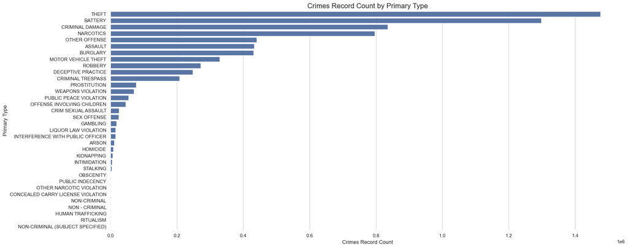

```python
plt.rcParams["figure.figsize"] = [20, 8]
sns.set(style="whitegrid")
sns.set_color_codes("pastel")
type_graph = sns.barplot(x='count', y='Primary Type', data=crime_type_counts_pd)
type_graph.set(ylabel="Primary Type", xlabel="Crimes Record Count")
sns.despine(left=True, bottom=True)
plt.title('Crimes Record Count by Primary Type', fontsize=16)
plt.tight_layout()
plt.show()
```

#### How have arrests evolved over the 16 years?

```python
df = df.withColumn('date_time', to_timestamp('date', 'MM/dd/yyyy hh:mm:ss a'))\
       .withColumn('month', trunc('date_time', 'YYYY'))
```

```python
df.select(['date','date_time', 'month'])\
  .show(n=2, truncate=False)
```

```
+----------------------+-------------------+----------+
|date                  |date_time          |month     |
+----------------------+-------------------+----------+
|01/01/2001 09:00:00 AM|2001-01-01 09:00:00|2001-01-01|
|10/19/2001 12:00:00 PM|2001-10-19 12:00:00|2001-01-01|
+----------------------+-------------------+----------+
only showing top 2 rows
```

```python
type_arrest_date = df.groupBy(['arrest', 'month'])\
                     .count()\
                     .orderBy(['month', 'count'], ascending=[True, False])
print()
type_arrest_date.show(3, truncate=False)
```

```
+------+----------+------+
|arrest|month     |count |
+------+----------+------+
|False |2001-01-01|3661  |
|True  |2001-01-01|1034  |
|False |2002-01-01|248784|
+------+----------+------+
only showing top 3 rows
```

```python
df.select(min('date').alias('first_record_date'), max('date').alias('latest_record_date')).show(truncate=False)
```

```
+----------------------+----------------------+
|first_record_date     |latest_record_date    |
+----------------------+----------------------+
|01/01/2001 01:00:00 AM|12/31/2016 12:56:00 AM|
+----------------------+----------------------+
```

```python
type_arrest_pddf = type_arrest_date.toPandas()
```

```python
type_arrest_pddf['yearpd'] = type_arrest_pddf['month'].apply(lambda dt: datetime.datetime.strftime(pd.Timestamp(dt), '%Y'))
type_arrest_pddf['arrest'] = type_arrest_pddf['arrest'].apply(lambda l: l=='True')
```

```python
type_arrest_pddf.head()
```

|  | arrest | month | count | yearpd |
| --- | --- | --- | --- | --- |
| 0 | False | 2001-01-01 | 3661 | 2001 |
| 1 | True | 2001-01-01 | 1034 | 2001 |
| 2 | False | 2002-01-01 | 248784 | 2002 |
| 3 | True | 2002-01-01 | 96185 | 2002 |
| 4 | False | 2003-01-01 | 330854 | 2003 |

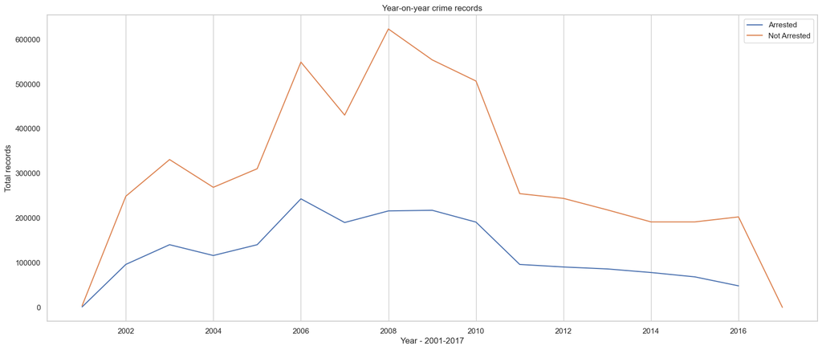

```python
t = type_arrest_pddf['count'] - 20
s = type_arrest_pddf['month']

arrested = type_arrest_pddf[type_arrest_pddf['arrest'] == True]
not_arrested = type_arrest_pddf[type_arrest_pddf['arrest'] == False]

fig, ax = plt.subplots()
ax.plot(arrested['month'], arrested['count'], label='Arrested')
ax.plot(not_arrested['month'], not_arrested['count'], label='Not Arrested')

ax.set(xlabel='Year - 2001-2017', ylabel='Total records',
       title='Year-on-year crime records')
ax.grid(which='both', axis='y')
ax.legend()
```

#### What time of the day are ciminal the busiest?

```python
df_hour = df.withColumn('hour', hour(df['date_time']))
```

```python
hourly_count = df_hour.groupBy(['Primary Type', 'hour']).count().cache()
hourly_total_count = hourly_count.groupBy('hour').sum('count')
```

```python
hourly_count_pddf = hourly_total_count.select(hourly_total_count['hour'], hourly_total_count['sum(count)'].alias('count')).toPandas()
```

```python
hourly_count_pddf = hourly_count_pddf.sort_values(by='hour')
```

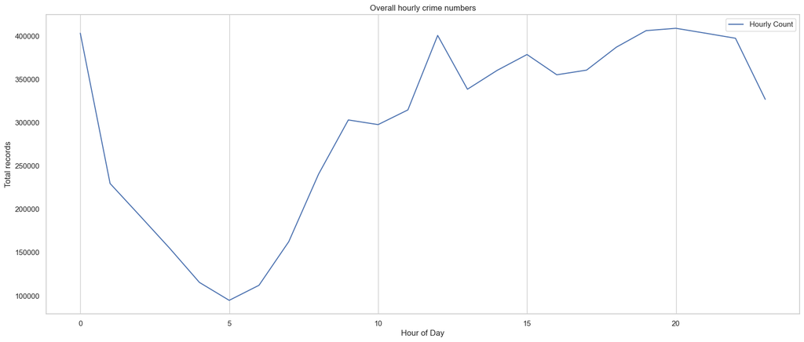

```python
fig, ax = plt.subplots()
ax.plot(hourly_count_pddf['hour'], hourly_count_pddf['count'], label='Hourly Count')

ax.set(xlabel='Hour of Day', ylabel='Total records',
       title='Overall hourly crime numbers')
ax.grid(which='both', axis='y')
ax.legend()
```

Peak hours appear to be between 3 PM and midnight.

#### What are the top 10 places where crime occurred?

```python
df.groupBy(['Location Description']).count().orderBy('count', ascending=False).show(10)
```

```
+--------------------+-------+
|Location Description|  count|
+--------------------+-------+
|              STREET|1868059|
|           RESIDENCE|1179074|
|            SIDEWALK| 767843|
|           APARTMENT| 759648|
|               OTHER| 257795|
|PARKING LOT/GARAG...| 200347|
|               ALLEY| 164167|
|SCHOOL, PUBLIC, B...| 155693|
|    RESIDENCE-GARAGE| 143065|
|RESIDENCE PORCH/H...| 124827|
+--------------------+-------+
only showing top 10 rows
```

#### A closer look at crime date and time

```python
df_dates = df_hour.withColumn('week_day', dayofweek(df_hour['date_time']))\
                 .withColumn('year_month', month(df_hour['date_time']))\
                 .withColumn('month_day', dayofmonth(df_hour['date_time']))\
                 .withColumn('date_number', datediff(df['date_time'], to_date(lit('2001-01-01'), format='yyyy-MM-dd')))\
                 .cache()
```

```python
df_dates.select(['date', 'month', 'hour', 'week_day', 'year', 'year_month', 'month_day', 'date_number']).show(20, truncate=False)
```

```
+----------------------+----------+----+--------+----+----------+---------+-----------+
|date                  |month     |hour|week_day|year|year_month|month_day|date_number|
+----------------------+----------+----+--------+----+----------+---------+-----------+
|01/01/2001 09:00:00 AM|2001-01-01|9   |2       |2001|1         |1        |0          |
|10/19/2001 12:00:00 PM|2001-01-01|12  |6       |2001|10        |19       |291        |
|01/26/2002 10:50:00 PM|2002-01-01|22  |7       |2002|1         |26       |390        |
|06/19/2001 12:00:00 AM|2001-01-01|0   |3       |2001|6         |19       |169        |
|02/03/2002 04:30:00 AM|2002-01-01|4   |1       |2002|2         |3        |398        |
|11/05/2001 08:00:00 AM|2001-01-01|8   |2       |2001|11        |5        |308        |
|01/06/2002 06:49:58 PM|2002-01-01|18  |1       |2002|1         |6        |370        |
|08/31/2001 12:00:00 AM|2001-01-01|0   |6       |2001|8         |31       |242        |
|12/23/2001 04:00:00 PM|2001-01-01|16  |1       |2001|12        |23       |356        |
|08/15/2001 08:00:00 AM|2001-01-01|8   |4       |2001|8         |15       |226        |
|04/01/2001 08:48:00 AM|2001-01-01|8   |1       |2001|4         |1        |90         |
|11/18/2001 11:30:00 AM|2001-01-01|11  |1       |2001|11        |18       |321        |
|03/26/2002 10:20:00 PM|2002-01-01|22  |3       |2002|3         |26       |449        |
|03/02/2002 11:00:00 AM|2002-01-01|11  |7       |2002|3         |2        |425        |
|01/13/2001 12:21:00 PM|2001-01-01|12  |7       |2001|1         |13       |12         |
|07/12/2001 06:40:00 PM|2001-01-01|18  |5       |2001|7         |12       |192        |
|08/30/2002 01:05:00 AM|2002-01-01|1   |6       |2002|8         |30       |606        |
|04/06/2003 02:35:00 PM|2003-01-01|14  |1       |2003|4         |6        |825        |
|08/18/2001 01:55:00 AM|2001-01-01|1   |7       |2001|8         |18       |229        |
|12/17/2001 09:00:00 PM|2001-01-01|21  |2       |2001|12        |17       |350        |
+----------------------+----------+----+--------+----+----------+---------+-----------+
only showing top 20 rows
```

#### Crime Rate based on Day of the Week

```python
week_day_crime_counts = df_dates.groupBy('week_day').count()
```

```python
week_day_crime_counts_pddf = week_day_crime_counts.orderBy('week_day').toPandas()
```

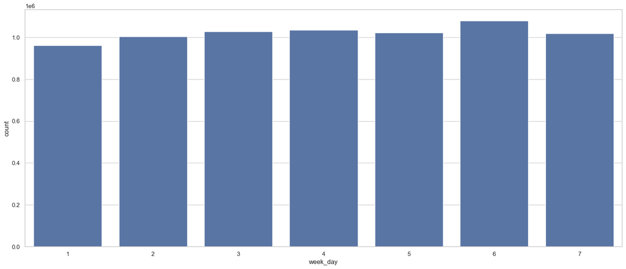

```python
sns.barplot(data=week_day_crime_counts_pddf, x='week_day', y='count')
```

#### Crime Rate based on Month of the Year

```python
year_month_crime_counts = df_dates.groupBy('year_month').count()
```

```python
year_month_crime_counts_pddf = year_month_crime_counts.orderBy('year_month').toPandas()
```

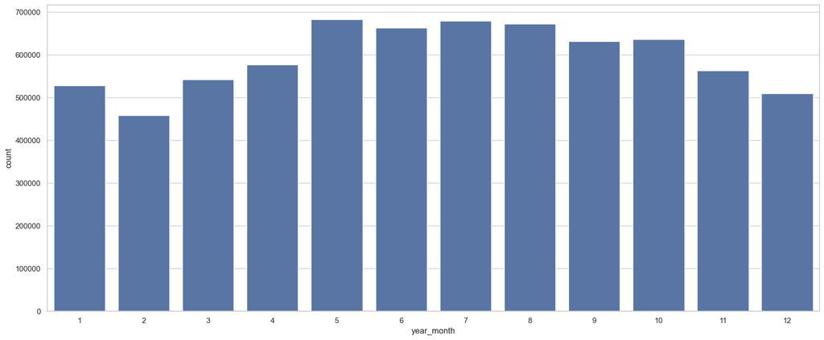

```python
sns.barplot(data=year_month_crime_counts_pddf, y='count', x='year_month')
```

#### Crime Rate based on Day of the Month

```python
month_day_crime_counts = df_dates.groupBy('month_day').count()
```

```python
month_day_crime_counts_pddf = month_day_crime_counts.orderBy('month_day').toPandas()
```

```python
month_day_crime_counts_pddf.sort_values(by='count', ascending=False).head(10)
```

|  | month_day | count |
| --- | --- | --- |
| 0 | 1 | 269528 |
| 14 | 15 | 243325 |
| 19 | 20 | 238389 |
| 13 | 14 | 237303 |
| 16 | 17 | 236405 |
| 9 | 10 | 236306 |
| 11 | 12 | 235766 |
| 15 | 16 | 234988 |
| 17 | 18 | 234238 |
| 8 | 9 | 233840 |

```python
month_day_crime_counts_pddf = month_day_crime_counts_pddf.sort_values(by='month_day', ascending=True)
```

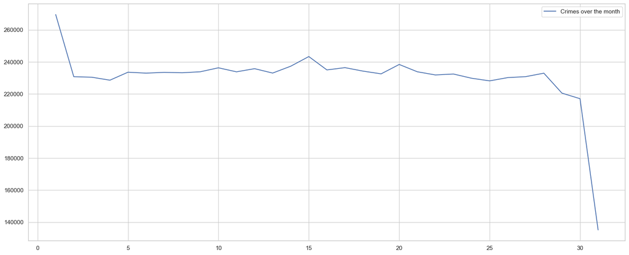

```python
fg, ax = plt.subplots()
ax.plot(month_day_crime_counts_pddf['month_day'], month_day_crime_counts_pddf['count'], label='Crimes over the month')
ax.grid(True)
ax.legend()
```

### Clustering

```python
# Convert Latitude and Longitude from String to Float
df = df.withColumn("Latitude", col("Latitude").cast("float"))
df = df.withColumn("Longitude", col("Longitude").cast("float"))

# Now, drop rows with null values again if any are introduced after conversion
df_features = df.select("Latitude", "Longitude").na.drop()

# Assemble features into a vector
vector_assembler = VectorAssembler(inputCols=["Latitude", "Longitude"], outputCol="features")
df_features_vector = vector_assembler.transform(df_features)

# Train the K-means model
kmeans = KMeans(k=6, seed=1)
model = kmeans.fit(df_features_vector)

# Get cluster predictions
df_clustered = model.transform(df_features_vector)

# Show the clustered data
df_clustered.show(5)
```

```
+--------+----------+--------------------+----------+
|Latitude| Longitude|            features|prediction|
+--------+----------+--------------------+----------+
|42.00748| -87.77408|[42.0074806213378...|         5|
|41.88615|-87.631134|[41.8861503601074...|         0|
|41.77816|  -87.7019|[41.7781600952148...|         4|
|41.74348| -87.55988|[41.7434806823730...|         1|
|41.88049| -87.74589|[41.8804893493652...|         2|
+--------+----------+--------------------+----------+
only showing top 5 rows
```

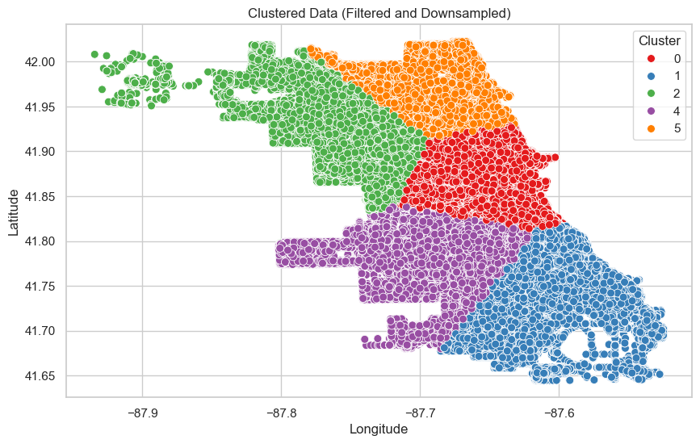

```python
# Assuming df_clustered is a Spark DataFrame, convert to Pandas
df_pandas = df_clustered.select("Latitude", "Longitude", "prediction").toPandas()

# Filter the DataFrame for the specified latitude and longitude range
filtered_df = df_pandas[(df_pandas['Latitude'] >= 40) & (df_pandas['Latitude'] <= 44) &
                        (df_pandas['Longitude'] >= -88) & (df_pandas['Longitude'] <= -86)].copy()

# Downsample the data if necessary (e.g., to 1000 points)
downsampled_df = filtered_df.sample(frac=0.40, random_state=42)

# Plot clusters with different colors using seaborn
plt.figure(figsize=(10, 6))
sns.scatterplot(x='Longitude', y='Latitude', hue='prediction', palette='Set1', data=downsampled_df, s=50)

# Customize the plot
plt.title('Clustered Data (Filtered and Downsampled)')
plt.xlabel('Longitude')
plt.ylabel('Latitude')
plt.legend(title='Cluster')
plt.grid(True)

# Show the plot
plt.show()
```

```python
# Define the number of clusters
n_clusters = 5

# Empty list to store clustered data for each crime type
crime_clusters = []

# Loop through each unique 'Primary Type' in the PySpark DataFrame
for crime_type in df.select("Primary Type").distinct().collect():
    crime_type_value = crime_type[0]

    # Filter the DataFrame for the current crime type
    crime_df = df.filter(F.col("Primary Type") == crime_type_value)

    # Filter out rows with null values in 'Latitude' or 'Longitude'
    crime_df = crime_df.na.drop(subset=["Latitude", "Longitude"])

    # Convert 'Latitude' and 'Longitude' to a vector column
    vector_assembler = VectorAssembler(inputCols=["Latitude", "Longitude"], outputCol="features")
    crime_df_vector = vector_assembler.transform(crime_df)

    # Perform KMeans clustering
    kmeans = KMeans(k=n_clusters, seed=42, featuresCol="features", predictionCol="Cluster")
    model = kmeans.fit(crime_df_vector)

    # Add the cluster predictions to the DataFrame
    crime_df_clustered = model.transform(crime_df_vector).select("Latitude", "Longitude", "Primary Type", "Cluster")

    # Convert to Pandas for plotting
    crime_df_pandas = crime_df_clustered.toPandas()

    # Append the Pandas DataFrame to the list
    crime_clusters.append(crime_df_pandas)

# Concatenate all the Pandas DataFrames into one
clustered_df = pd.concat(crime_clusters)
```

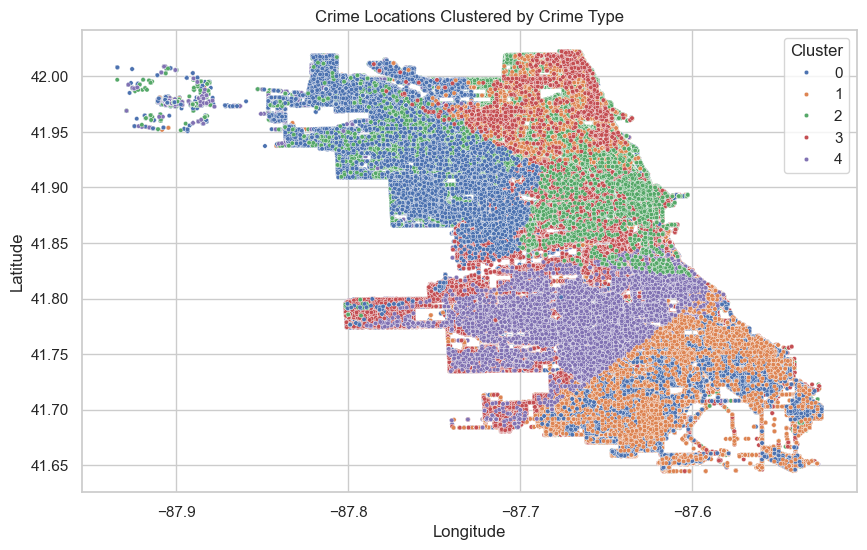

```python
# Filter the concatenated Pandas DataFrame based on the latitude and longitude range
filtered_df = clustered_df[(clustered_df['Latitude'] >= 40) & (clustered_df['Latitude'] <= 44) &
                           (clustered_df['Longitude'] >= -88) & (clustered_df['Longitude'] <= -86)].copy()

# Plotting the clustered crime locations
plt.figure(figsize=(10, 6))

# Use Seaborn to create a scatter plot, coloring by the cluster number
sns.scatterplot(data=filtered_df, x="Longitude", y="Latitude", hue="Cluster", palette="deep", s=10)

# Add title and labels
plt.title("Crime Locations Clustered by Crime Type")
plt.xlabel("Longitude")
plt.ylabel("Latitude")

# Show plot
plt.show()
```

### Prediction Model Using Logistic Regression

Building a model to predict what kind of crime is going to occur given the selected features.

```python
df.columns
```

```
['_c0',
 'ID',
 'Case Number',
 'Date',
 'Block',
 'IUCR',
 'Primary Type',
 'Description',
 'Location Description',
 'Arrest',
 'Domestic',
 'Beat',
 'District',
 'Ward',
 'Community Area',
 'FBI Code',
 'X Coordinate',
 'Y Coordinate',
 'Year',
 'Updated On',
 'Latitude',
 'Longitude',
 'Location',
 'date_time',
 'month']
```

```python
selected_features = [
 'Location Description',
 'Arrest',
 'Domestic',
 'Beat',
 'District',
 'Ward',
 'Community Area',
 'FBI Code',
 'hour',
 'week_day',
 'year_month',
 'month_day',
 'date_number']
```

```python
#Let's see the schema of these selected features:
features_df = df_dates.select(selected_features)
features_df.printSchema()
```

```
root
 |-- Location Description: string (nullable = true)
 |-- Arrest: string (nullable = true)
 |-- Domestic: string (nullable = true)
 |-- Beat: string (nullable = true)
 |-- District: string (nullable = true)
 |-- Ward: string (nullable = true)
 |-- Community Area: string (nullable = true)
 |-- FBI Code: string (nullable = true)
 |-- hour: integer (nullable = true)
 |-- week_day: integer (nullable = true)
 |-- year_month: integer (nullable = true)
 |-- month_day: integer (nullable = true)
 |-- date_number: integer (nullable = true)
```

```python
feature_level_count_dic = []

for feature in selected_features:
    print('Analysing %s' % feature)
    levels_list_df = features_df.select(feature).distinct()
    feature_level_count_dic.append({'feature': feature, 'level_count': levels_list_df.count()})
```

```
Analysing Location Description
Analysing Arrest
Analysing Domestic
Analysing Beat
Analysing District
Analysing Ward
Analysing Community Area
Analysing FBI Code
Analysing hour
Analysing week_day
Analysing year_month
Analysing month_day
Analysing date_number
```

```python
pd.DataFrame(feature_level_count_dic).sort_values(by='level_count', ascending=False)
```

|  | feature | level_count |
| --- | --- | --- |
| 12 | date_number | 5855 |
| 3 | Beat | 303 |
| 0 | Location Description | 170 |
| 6 | Community Area | 78 |
| 5 | Ward | 50 |
| 11 | month_day | 31 |
| 4 | District | 26 |
| 7 | FBI Code | 26 |
| 8 | hour | 24 |
| 10 | year_month | 12 |
| 9 | week_day | 7 |
| 1 | Arrest | 2 |
| 2 | Domestic | 2 |

```python
df_dates_features = df_dates.na.drop(subset=selected_features)
```

```python
for feature in feature_level_count_dic:
    indexer = StringIndexer(inputCol=feature['feature'], outputCol='%s_indexed' % feature['feature'])
    print('Fitting feature "%s"' % feature['feature'])
    model = indexer.fit(df_dates_features)
    print('Transforming "%s"' % feature['feature'])
    df_dates_features = model.transform(df_dates_features)
```

```
Fitting feature "Location Description"
Transforming "Location Description"
Fitting feature "Arrest"
Transforming "Arrest"
Fitting feature "Domestic"
Transforming "Domestic"
Fitting feature "Beat"
Transforming "Beat"
Fitting feature "District"
Transforming "District"
Fitting feature "Ward"
Transforming "Ward"
Fitting feature "Community Area"
Transforming "Community Area"
Fitting feature "FBI Code"
Transforming "FBI Code"
Fitting feature "hour"
Transforming "hour"
Fitting feature "week_day"
Transforming "week_day"
Fitting feature "year_month"
Transforming "year_month"
Fitting feature "month_day"
Transforming "month_day"
Fitting feature "date_number"
Transforming "date_number"
```

```python
df_dates_features.printSchema()
```

```
root
 |-- _c0: integer (nullable = true)
 |-- ID: integer (nullable = true)
 |-- Case Number: string (nullable = true)
 |-- Date: string (nullable = true)
 |-- Block: string (nullable = true)
 |-- IUCR: string (nullable = true)
 |-- Primary Type: string (nullable = true)
 |-- Description: string (nullable = true)
 |-- Location Description: string (nullable = true)
 |-- Arrest: string (nullable = true)
 |-- Domestic: string (nullable = true)
 |-- Beat: string (nullable = true)
 |-- District: string (nullable = true)
 |-- Ward: string (nullable = true)
 |-- Community Area: string (nullable = true)
 |-- FBI Code: string (nullable = true)
 |-- X Coordinate: string (nullable = true)
 |-- Y Coordinate: string (nullable = true)
 |-- Year: string (nullable = true)
 |-- Updated On: string (nullable = true)
 |-- Latitude: string (nullable = true)
 |-- Longitude: string (nullable = true)
 |-- Location: string (nullable = true)
 |-- date_time: timestamp (nullable = true)
 |-- month: date (nullable = true)
 |-- hour: integer (nullable = true)
 |-- week_day: integer (nullable = true)
 |-- year_month: integer (nullable = true)
 |-- month_day: integer (nullable = true)
 |-- date_number: integer (nullable = true)
 |-- Location Description_indexed: double (nullable = false)
 |-- Arrest_indexed: double (nullable = false)
 |-- Domestic_indexed: double (nullable = false)
 |-- Beat_indexed: double (nullable = false)
 |-- District_indexed: double (nullable = false)
 |-- Ward_indexed: double (nullable = false)
 |-- Community Area_indexed: double (nullable = false)
 |-- FBI Code_indexed: double (nullable = false)
 |-- hour_indexed: double (nullable = false)
 |-- week_day_indexed: double (nullable = false)
 |-- year_month_indexed: double (nullable = false)
 |-- month_day_indexed: double (nullable = false)
 |-- date_number_indexed: double (nullable = false)
```

```python
## String-index the response variable:
response_indexer = StringIndexer(inputCol='Primary Type', outputCol='primary_type_indexed')
response_model = response_indexer.fit(df_dates_features)
df_dates_features = response_model.transform(df_dates_features)
```

```python
indexed_features = ['%s_indexed' % fc['feature'] for fc in feature_level_count_dic]
indexed_features
```

```
['Location Description_indexed',
 'Arrest_indexed',
 'Domestic_indexed',
 'Beat_indexed',
 'District_indexed',
 'Ward_indexed',
 'Community Area_indexed',
 'FBI Code_indexed',
 'hour_indexed',
 'week_day_indexed',
 'year_month_indexed',
 'month_day_indexed',
 'date_number_indexed']
```

```python
assembler = VectorAssembler(inputCols=indexed_features, outputCol='features')
vectorized_df_dates = assembler.transform(df_dates_features)
```

```python
vectorized_df_dates.select('features').take(1)
```

```
[Row(features=DenseVector([1.0, 0.0, 0.0, 280.0, 18.0, 43.0, 74.0, 0.0, 14.0, 5.0, 9.0, 0.0, 5311.0]))]
```

```python
train, test = vectorized_df_dates.randomSplit([0.6, 0.4])
```

```python
logisticRegression = LogisticRegression(labelCol='primary_type_indexed', featuresCol='features', maxIter=10, family='multinomial')
```

```python
fittedModel = logisticRegression.fit(train)
```

```python
fittedModel.summary.accuracy
```

```
0.6248349392249726
```

```python
model_summary = fittedModel.summary
```

```python
fittedModel.coefficientMatrix
```

```
DenseMatrix(34, 13, [0.0098, -1.328, 0.1064, 0.0003, -0.0014, 0.0045, -0.0016, -3.4195, ..., 0.0, 0.0, -0.0, 0.0, -0.0, 0.0001, 0.0, 0.0], 1)
```

```python
label_stats = {float(i):{'index': float(i)} for i in range(34)}
print(label_stats)
```

[output not shown]

```python
print("False positive rate by label:")
for i, rate in enumerate(model_summary.falsePositiveRateByLabel):
    label_stats[i]['false_positive_rate'] = rate

for i, rate in enumerate(model_summary.truePositiveRateByLabel):
    label_stats[i]['true_positive_rate'] = rate

for i, rate in enumerate(model_summary.precisionByLabel):
    label_stats[i]['precision_rate'] = rate

for i, rate in enumerate(model_summary.recallByLabel):
    label_stats[i]['recall_rate'] = rate

for i, rate in enumerate(model_summary.fMeasureByLabel()):
    label_stats[i]['f_measure'] = rate
```

```
False positive rate by label:
```

```python
train.printSchema()
```

```
root
 |-- _c0: integer (nullable = true)
 |-- ID: integer (nullable = true)
 |-- Case Number: string (nullable = true)
 |-- Date: string (nullable = true)
 |-- Block: string (nullable = true)
 |-- IUCR: string (nullable = true)
 |-- Primary Type: string (nullable = true)
 |-- Description: string (nullable = true)
 |-- Location Description: string (nullable = true)
 |-- Arrest: string (nullable = true)
 |-- Domestic: string (nullable = true)
 |-- Beat: string (nullable = true)
 |-- District: string (nullable = true)
 |-- Ward: string (nullable = true)
 |-- Community Area: string (nullable = true)
 |-- FBI Code: string (nullable = true)
 |-- X Coordinate: string (nullable = true)
 |-- Y Coordinate: string (nullable = true)
 |-- Year: string (nullable = true)
 |-- Updated On: string (nullable = true)
 |-- Latitude: string (nullable = true)
 |-- Longitude: string (nullable = true)
 |-- Location: string (nullable = true)
 |-- date_time: timestamp (nullable = true)
 |-- month: date (nullable = true)
 |-- hour: integer (nullable = true)
 |-- week_day: integer (nullable = true)
 |-- year_month: integer (nullable = true)
 |-- month_day: integer (nullable = true)
 |-- date_number: integer (nullable = true)
 |-- Location Description_indexed: double (nullable = false)
 |-- Arrest_indexed: double (nullable = false)
 |-- Domestic_indexed: double (nullable = false)
 |-- Beat_indexed: double (nullable = false)
 |-- District_indexed: double (nullable = false)
 |-- Ward_indexed: double (nullable = false)
 |-- Community Area_indexed: double (nullable = false)
 |-- FBI Code_indexed: double (nullable = false)
 |-- hour_indexed: double (nullable = false)
 |-- week_day_indexed: double (nullable = false)
 |-- year_month_indexed: double (nullable = false)
 |-- month_day_indexed: double (nullable = false)
 |-- date_number_indexed: double (nullable = false)
 |-- primary_type_indexed: double (nullable = false)
 |-- features: vector (nullable = true)
```

```python
train_rdd = train.select(['Primary Type', 'primary_type_indexed']).distinct().orderBy('primary_type_indexed').toPandas()
for _, l in train_rdd.iterrows():
    label_stats[l['primary_type_indexed']]['Primary Type'] = l['Primary Type']
```

```python
rates_pddf = pd.DataFrame(list(label_stats.values()))
rates_pddf = rates_pddf.sort_values(by='precision_rate', ascending=False)
```

```python
rates_pddf
```

|  | index | false_positive_rate | true_positive_rate | precision_rate | recall_rate | f_measure | Primary Type |
| --- | --- | --- | --- | --- | --- | --- | --- |
| 0 | 0.0 | 0.031780 | 0.983481 | 0.889725 | 0.983481 | 0.934257 | THEFT |
| 14 | 14.0 | 0.000376 | 0.177150 | 0.752127 | 0.177150 | 0.286759 | OFFENSE INVOLVING CHILDREN |
| 2 | 2.0 | 0.049748 | 0.826838 | 0.687753 | 0.826838 | 0.750910 | CRIMINAL DAMAGE |
| 3 | 3.0 | 0.060463 | 0.967499 | 0.667139 | 0.967499 | 0.789724 | NARCOTICS |
| 6 | 6.0 | 0.036508 | 0.819984 | 0.589985 | 0.819984 | 0.686225 | BURGLARY |
| 1 | 1.0 | 0.084784 | 0.396356 | 0.509041 | 0.396356 | 0.445686 | BATTERY |
| 7 | 7.0 | 0.031214 | 0.627967 | 0.492043 | 0.627967 | 0.551757 | MOTOR VEHICLE THEFT |
| 10 | 10.0 | 0.007147 | 0.197099 | 0.452317 | 0.197099 | 0.274558 | CRIMINAL TRESPASS |
| 11 | 11.0 | 0.010390 | 0.672811 | 0.412654 | 0.672811 | 0.511556 | PROSTITUTION |
| 5 | 5.0 | 0.037148 | 0.383411 | 0.399673 | 0.383411 | 0.391373 | ASSAULT |
| 9 | 9.0 | 0.026067 | 0.428686 | 0.371148 | 0.428686 | 0.397848 | DECEPTIVE PRACTICE |
| 12 | 12.0 | 0.002117 | 0.103307 | 0.326814 | 0.103307 | 0.156989 | WEAPONS VIOLATION |
| 8 | 8.0 | 0.026718 | 0.282151 | 0.294293 | 0.282151 | 0.288094 | ROBBERY |
| 4 | 4.0 | 0.002383 | 0.010030 | 0.216912 | 0.010030 | 0.019174 | OTHER OFFENSE |
| 17 | 17.0 | 0.005793 | 0.652962 | 0.216525 | 0.652962 | 0.325209 | GAMBLING |
| 15 | 15.0 | 0.000810 | 0.031461 | 0.122940 | 0.031461 | 0.050101 | CRIM SEXUAL ASSAULT |
| 18 | 18.0 | 0.003440 | 0.229481 | 0.122548 | 0.229481 | 0.159773 | LIQUOR LAW VIOLATION |
| 16 | 16.0 | 0.001027 | 0.033422 | 0.100267 | 0.033422 | 0.050133 | SEX OFFENSE |
| 21 | 21.0 | 0.000085 | 0.006206 | 0.078086 | 0.006206 | 0.011499 | HOMICIDE |
| 26 | 26.0 | 0.000000 | 0.000000 | 0.000000 | 0.000000 | 0.000000 | PUBLIC INDECENCY |
| 32 | 32.0 | 0.000000 | 0.000000 | 0.000000 | 0.000000 | 0.000000 | RITUALISM |
| 31 | 31.0 | 0.000000 | 0.000000 | 0.000000 | 0.000000 | 0.000000 | HUMAN TRAFFICKING |
| 30 | 30.0 | 0.000000 | 0.000000 | 0.000000 | 0.000000 | 0.000000 | NON - CRIMINAL |
| 29 | 29.0 | 0.000000 | 0.000000 | 0.000000 | 0.000000 | 0.000000 | NON-CRIMINAL |
| 28 | 28.0 | 0.000000 | 0.000000 | 0.000000 | 0.000000 | 0.000000 | CONCEALED CARRY LICENSE VIOLATION |
| 27 | 27.0 | 0.000000 | 0.000000 | 0.000000 | 0.000000 | 0.000000 | OTHER NARCOTIC VIOLATION |
| 24 | 24.0 | 0.000000 | 0.000000 | 0.000000 | 0.000000 | 0.000000 | STALKING |
| 25 | 25.0 | 0.000000 | 0.000000 | 0.000000 | 0.000000 | 0.000000 | OBSCENITY |
| 23 | 23.0 | 0.000000 | 0.000000 | 0.000000 | 0.000000 | 0.000000 | INTIMIDATION |
| 22 | 22.0 | 0.000000 | 0.000000 | 0.000000 | 0.000000 | 0.000000 | KIDNAPPING |
| 20 | 20.0 | 0.000000 | 0.000000 | 0.000000 | 0.000000 | 0.000000 | ARSON |
| 19 | 19.0 | 0.000000 | 0.000000 | 0.000000 | 0.000000 | 0.000000 | INTERFERENCE WITH PUBLIC OFFICER |
| 13 | 13.0 | 0.000000 | 0.000000 | 0.000000 | 0.000000 | 0.000000 | PUBLIC PEACE VIOLATION |
| 33 | 33.0 | 0.000000 | 0.000000 | 0.000000 | 0.000000 | 0.000000 | NON-CRIMINAL (SUBJECT SPECIFIED) |

### Decision Tree Classifier

Using Decision Tree Classifier to figure out what are the major features contributing to arrest.

```python
dt_df = df.select("Arrest", "Primary Type", "Location Description", "Domestic", "Beat", "District", "Ward", "Community Area", "FBI Code", "Year")
```

```python
# Filter non-numeric values and cast to integer
df = df.filter(F.col("Beat").cast("integer").isNotNull() &
               F.col("District").cast("integer").isNotNull() &
               F.col("Ward").cast("integer").isNotNull() &
               F.col("Community Area").cast("integer").isNotNull() &
               F.col("Year").cast("integer").isNotNull())

# Now proceed with casting
dt_df = df.select("Arrest", "Primary Type", "Location Description", "Domestic", "Beat", "District", "Ward", "Community Area", "FBI Code", "Year") \
           .withColumn("Beat", F.col("Beat").cast("integer")) \
           .withColumn("District", F.col("District").cast("integer")) \
           .withColumn("Ward", F.col("Ward").cast("integer")) \
           .withColumn("Community Area", F.col("Community Area").cast("integer")) \
           .withColumn("Year", F.col("Year").cast("integer"))

# Verify the schema to check the types
dt_df.printSchema()
```

```
root
 |-- Arrest: string (nullable = true)
 |-- Primary Type: string (nullable = true)
 |-- Location Description: string (nullable = true)
 |-- Domestic: string (nullable = true)
 |-- Beat: integer (nullable = true)
 |-- District: integer (nullable = true)
 |-- Ward: integer (nullable = true)
 |-- Community Area: integer (nullable = true)
 |-- FBI Code: string (nullable = true)
 |-- Year: integer (nullable = true)
```

```python
# Index categorical columns for use in the decision tree, with handleInvalid set to "keep"
arrest_indexer = StringIndexer(inputCol="Arrest", outputCol="label", handleInvalid="keep")
primary_type_indexer = StringIndexer(inputCol="Primary Type", outputCol="primary_type_index", handleInvalid="keep")
location_desc_indexer = StringIndexer(inputCol="Location Description", outputCol="location_desc_index", handleInvalid="keep")
domestic_indexer = StringIndexer(inputCol="Domestic", outputCol="domestic_index", handleInvalid="keep")
fbi_code_indexer = StringIndexer(inputCol="FBI Code", outputCol="fbi_code_index", handleInvalid="keep")
```

```python
# Assemble features into a single vector
assembler = VectorAssembler(inputCols=["primary_type_index", "location_desc_index", "domestic_index",
                                       "Beat", "District", "Ward", "Community Area",
                                       "fbi_code_index", "Year"], outputCol="features")

# Define the Decision Tree Classifier
dt = DecisionTreeClassifier(featuresCol="features", labelCol="label",maxBins=180)

# Build the pipeline
pipeline = Pipeline(stages=[arrest_indexer, primary_type_indexer, location_desc_indexer, domestic_indexer, fbi_code_indexer, assembler, dt])

# Split data into training and test sets (80% train, 20% test)
train_data, test_data = df.randomSplit([0.8, 0.2])

# Train the model
model = pipeline.fit(train_data)

# Test the model
predictions = model.transform(test_data)
```

```python
# Evaluate the model
evaluator = MulticlassClassificationEvaluator(labelCol="label", predictionCol="prediction", metricName="accuracy")
accuracy = evaluator.evaluate(predictions)
print(f"Test Accuracy: {accuracy}")
```

```
Test Accuracy: 0.8646558526593839
```

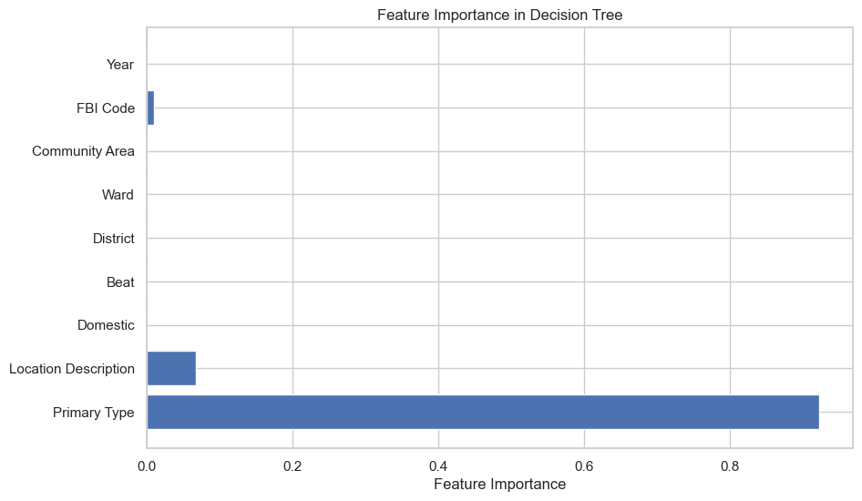

```python
tree_model = model.stages[-1]
# Get feature importances
importances = tree_model.featureImportances.toArray()

# Define feature names based on the order in the assembler
feature_names = ["Primary Type", "Location Description", "Domestic", "Beat", "District", "Ward", "Community Area", "FBI Code", "Year"]

# Plot feature importances
plt.figure(figsize=(10, 6))
plt.barh(np.arange(len(importances)), importances, align='center')
plt.yticks(np.arange(len(importances)), feature_names)
plt.xlabel('Feature Importance')
plt.title('Feature Importance in Decision Tree')
plt.show()
```

#### Finding out which Type of crimes leads to the most arrests

```python
# Group by Primary Type and Arrest to calculate the total arrests for each crime type
arrest_stats = df.groupBy("Primary Type").agg(
    F.count("Arrest").alias("total_cases"),  # Total number of cases for each crime type
    F.sum(F.when(F.col("Arrest") == True, 1).otherwise(0)).alias("total_arrests")  # Count of True (arrests)
)

# Calculate the arrest rate for each crime type
arrest_stats = arrest_stats.withColumn("arrest_rate", F.col("total_arrests") / F.col("total_cases"))

# Sort by arrest rate in descending order to see which crime types lead to the most arrests
arrest_stats = arrest_stats.orderBy(F.col("arrest_rate").desc())

# Show the results
arrest_stats.show(truncate=False)
```

```
+---------------------------------+-----------+-------------+-------------------+
|Primary Type                     |total_cases|total_arrests|arrest_rate        |
+---------------------------------+-----------+-------------+-------------------+
|PROSTITUTION                     |76768      |76347        |0.9945159441433931 |
|NARCOTICS                        |796053     |789727       |0.9920532929340132 |
|GAMBLING                         |17455      |17305        |0.9914064737897451 |
|LIQUOR LAW VIOLATION             |15115      |14945        |0.9887528944756864 |
|PUBLIC INDECENCY                 |149        |147          |0.9865771812080537 |
|INTERFERENCE WITH PUBLIC OFFICER |14993      |13673        |0.9119589141599413 |
|CONCEALED CARRY LICENSE VIOLATION|84         |72           |0.8571428571428571 |
|OBSCENITY                        |442        |367          |0.830316742081448  |
|WEAPONS VIOLATION                |70352      |56400        |0.8016829656584035 |
|CRIMINAL TRESPASS                |207722     |151448       |0.7290898412301057 |
|OTHER NARCOTIC VIOLATION         |133        |94           |0.706766917293233  |
|PUBLIC PEACE VIOLATION           |54362      |36507        |0.6715536588057834 |
|HOMICIDE                         |8344       |4083         |0.48933365292425696|
|SEX OFFENSE                      |24301      |7800         |0.3209744454960701 |
|NON-CRIMINAL (SUBJECT SPECIFIED) |4          |1            |0.25               |
|ASSAULT                          |432898     |102916       |0.237737296083604  |
|BATTERY                          |1298240    |298519       |0.22994130515158984|
|OFFENSE INVOLVING CHILDREN       |45568      |9659         |0.21196892556179775|
|DECEPTIVE PRACTICE               |247713     |45349        |0.18307073104762367|
|INTIMIDATION                     |4176       |726          |0.17385057471264367|
+---------------------------------+-----------+-------------+-------------------+
only showing top 20 rows
```

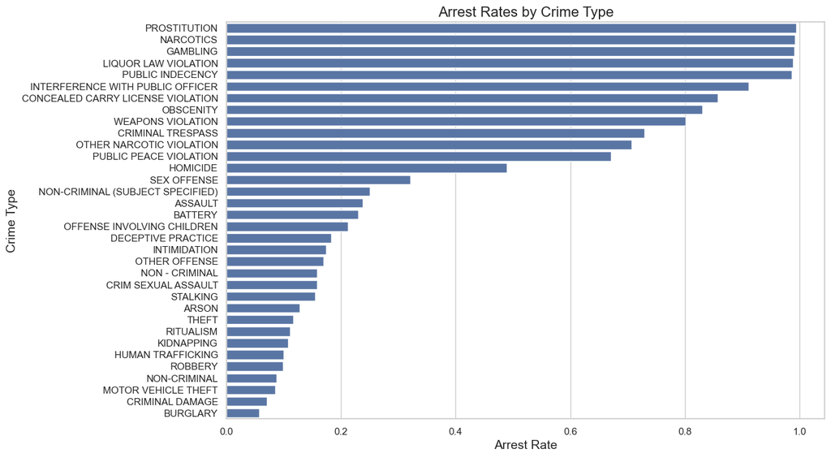

```python
# Convert Spark DataFrame to Pandas DataFrame
arrest_stats_pd = arrest_stats.toPandas()

# Import Seaborn and Matplotlib for visualization
import seaborn as sns
import matplotlib.pyplot as plt

# Set the size of the plot
plt.figure(figsize=(12, 8))

# Create a bar plot to visualize the arrest rates by primary type
sns.barplot(data=arrest_stats_pd, x='arrest_rate', y='Primary Type')

# Add titles and labels
plt.title('Arrest Rates by Crime Type', fontsize=16)
plt.xlabel('Arrest Rate', fontsize=14)
plt.ylabel('Crime Type', fontsize=14)

# Show the plot
plt.show()
```